# Exploratory Data Analysis on Amazon US Dataset

## I. Executive Summary

2.) Sellers under video games category must take extra action on its products, especially since 6 of its products belong to the bottom 10 (rated 1-star) in terms of product ratings.

3.) Reviews reach its peak during December and January due to long holidays. Sellers must be able to take advantage of this information by improving their product and selling more starting from September since there is an expected increase of purchasing capacity from customers during 'Ber' months. Customers, on the other hand, must take note of reviews from helpful customers (those that have highest helpful votes) and expect discounts due to product volume increase.

4.) We clearly saw the difference of star ratings between products with no vote and with helpful votes. Those with no votes are rated relatively higher than those with helpful votes already. Amazon needs to optimize its Vine Program so that it can assist the sellers on improving the quality and review ratings of their products.

## II. Introduction

Online shopping is one of the most prominent applications of e-commerce. It provides faster and low cost transactions, convenience, and more variety of options for sellers and customers compared to brick-and-mortar stores. Amazon, the biggest online retailer in terms of revenue and market capitalization worldwide, has the challenge to keep track of the reviews to understand the behavior of both its sellers and customers.

Prior to purchasing, Amazon customers tend to carefully read into product reviews. The absence of the ability to test a product before buying it makes the customers rely on these reviews. Typically most customers ignore average rating since they are more interested in those reviews with extreme ratings--reviews with 5-star and 1-star ratings.

Amazon sellers must be able to understand customer reviews in order to have higher rankings. Their businesses are greatly affected by reviews in such a way that if their product is given a bad review, they are at a risk of gaining bad reputation and eventually lose sales.

Amazon has been receiving million of reviews from its customers since 1995, in which opinions and experiences regarding products are shared. The rich amount of data Amazon provides can be used for academic research, particularly in Natural Language Processing and Machine Learning. This dataset is provided in order to understand customer product experiences through different methods other than what are previously mentioned.

The goal of our team is to provide a general overview of Amazon product reviews. Through this study, Amazon would know what products gained traction through the number of reviews, and the best and worst reviewed products. Additionally, looking at different product categories, Amazon would know which sellers and buyers to attract based on reviews and ratings. Understanding the nature and occurence of reviews postings, Amazon can help sellers plan the improvement of their products or release of new products.

## III. Data Collection and Description

The dataset is a collection of more than 130M customer reviews written in the Amazon.com marketplace (1995 to 2015). It is approximately 33GB in size, including associated metadata. There is a collection of reviews in multiple languages such as US, UK, Japan, France and Germany but we only covered US marketplace for this study. The dataset is separated into product categories in tab separated value (TSV) and gzip file format each. The list of URLs for all categories available can be seen in the Amazon Customer Reviews Dataset website. Each category contains the following fields:

- `marketplace` - 2-letter country code which indicates where the reviews are posted, e.g. US, UK, JP, FR, DE
- `customer_id` - unique customer id
- `review_id`- unique review id
- `product_id`-unique product id
- `product_parent`- the product displayed in search results
- `product_title`- name of the product
- `product_category`-category to which the product belongs to (e.g. Grocery, Shoes, Automotive, Electronics, Watches, Pet Products, Sports, Musical Instruments, Camera, Video Games)
- `star_rating` - product rating based on customer review
- `helpful_votes` - count of votes each review received
- `total_votes`-total votes the review received
- `vine`- Y(yes)/N(no); Y if the customer participates in the Vine program, N otherwise
- `verified_purchase`- Y(yes)/N(no); Y if the customer who posted the review actually bought the product, N otherwise
- `review_headline`- summary of the review
- `review_body`- actual feedback of the customer
- `review_date` - yyyy/mm/dd; the date the review is posted

The dataset for this study comes from categories chosen by our team, namely: *Grocery, Shoes, Automotive, Electronics, Watches, Pet Products, Sports, Musical Instruments, Camera and Video Games*.

## V. Exploratory Data Analysis

Our team has come up with several visualizations regarding on annual and monthly trend of products, customer engagements and product ratings. See graphs below.

```python
import numpy as np
import matplotlib.pyplot as plt
%matplotlib inline
import pandas as pd

import dask.dataframe as dd
from dask.diagnostics import ProgressBar

import warnings
warnings.filterwarnings('ignore')

pbar = ProgressBar()
pbar.register()
```

```python
dir_list =['/mnt/data/public/amazon-reviews/amazon_reviews_us_Grocery_v1_00.tsv.gz',
           '/mnt/data/public/amazon-reviews/amazon_reviews_us_Shoes_v1_00.tsv.gz',
           '/mnt/localdata/public/amazon-reviews/amazon_reviews_us_Automotive_v1_00.tsv.gz',
           '/mnt/localdata/public/amazon-reviews/amazon_reviews_us_Electronics_v1_00.tsv.gz',
           '/mnt/localdata/public/amazon-reviews/amazon_reviews_us_Watches_v1_00.tsv.gz',
           '/mnt/localdata/public/amazon-reviews/amazon_reviews_us_Pet_Products_v1_00.tsv.gz',
           '/mnt/localdata/public/amazon-reviews/amazon_reviews_us_Sports_v1_00.tsv.gz',
           '/mnt/localdata/public/amazon-reviews/amazon_reviews_us_Musical_Instruments_v1_00.tsv.gz',
           '/mnt/localdata/public/amazon-reviews/amazon_reviews_us_Camera_v1_00.tsv.gz',
           '/mnt/localdata/public/amazon-reviews/amazon_reviews_us_Video_Games_v1_00.tsv.gz']
```

```python
usecols = ['customer_id', 'review_id', 'product_title','product_category', 'star_rating','helpful_votes','total_votes', 'verified_purchase', 'review_date']
# usecols = ['review_date']
df = dd.read_csv(dir_list,
                 compression='gzip',
                 delimiter = '\t',
                 error_bad_lines=False,
                 warn_bad_lines=False,
                 blocksize=None,
                 dtype=str,usecols=usecols)
```

```python
#getting a sizeable amount of data to load that fits in RAM
df = df.sample(frac=0.5,random_state=42)

#removing NaNs
df = df.dropna()

# to remove erronous titles (in some cases, the actual review is in the product_title column)
# df = df[df.product_title.str.len() < 100]
```

```python
df.star_rating = df.star_rating.astype(int)
df.helpful_votes = df.helpful_votes.astype(int)
df.total_votes = df.total_votes.astype(int)
```

```python
df['year'] = df.review_date.apply(lambda x: str(x).split('-')[0],meta=str)
df['month'] = df.review_date.apply(lambda x: str(x).split('-')[1] if len(str(x).split('-')) > 1 else None,meta=str)
```

```python
df.describe().compute()
```

```
[########################################] | 100% Completed |  6min 12.1s
```

|  | star_rating | helpful_votes | total_votes |
| --- | --- | --- | --- |
| count | 1.313637e+07 | 1.313637e+07 | 1.313637e+07 |
| mean | 4.188407e+00 | 1.548516e+00 | 2.004574e+00 |
| std | 1.271332e+00 | 1.709807e+01 | 1.823632e+01 |
| min | 1.000000e+00 | 0.000000e+00 | 0.000000e+00 |
| 25% | 4.000000e+00 | 0.000000e+00 | 0.000000e+00 |
| 50% | 5.000000e+00 | 0.000000e+00 | 1.000000e+00 |
| 75% | 5.000000e+00 | 1.000000e+00 | 3.000000e+00 |
| max | 5.000000e+00 | 2.375500e+04 | 2.417000e+04 |

```python
# NO vote
df[df.total_votes == 0].describe().compute()
```

```
[########################################] | 100% Completed |  6min 16.7s
```

|  | star_rating | helpful_votes | total_votes |
| --- | --- | --- | --- |
| count | 7.996222e+06 | 7996222.0 | 7996222.0 |
| mean | 4.377569e+00 | 0.0 | 0.0 |
| std | 1.093744e+00 | 0.0 | 0.0 |
| min | 1.000000e+00 | 0.0 | 0.0 |
| 25% | 5.000000e+00 | 0.0 | 0.0 |
| 50% | 5.000000e+00 | 0.0 | 0.0 |
| 75% | 5.000000e+00 | 0.0 | 0.0 |
| max | 5.000000e+00 | 0.0 | 0.0 |

```python
# With helpful votes
df[df.helpful_votes > 1].describe().compute()
```

```
[########################################] | 100% Completed |  6min 21.4s
```

|  | star_rating | helpful_votes | total_votes |
| --- | --- | --- | --- |
| count | 2.230256e+06 | 2.230256e+06 | 2.230256e+06 |
| mean | 3.838477e+00 | 8.222153e+00 | 9.853726e+00 |
| std | 1.498505e+00 | 4.083564e+01 | 4.333382e+01 |
| min | 1.000000e+00 | 2.000000e+00 | 2.000000e+00 |
| 25% | 4.000000e+00 | 2.000000e+00 | 3.000000e+00 |
| 50% | 5.000000e+00 | 4.000000e+00 | 6.000000e+00 |
| 75% | 5.000000e+00 | 9.000000e+00 | 1.300000e+01 |
| max | 5.000000e+00 | 2.375500e+04 | 2.417000e+04 |

### Product per category with most number of reviews

In the horizontal barplot below, we can see which product per category received the most number of reviews. The Panasonic earphones received the most number of reviews as compared with others.

```
[                                        ] | 0% Completed |  0.1s
```

```
[########################################] | 100% Completed |  2min 53.2s
```

[figure not shown]

```python
df.groupby('product_category')['product_title'].apply(lambda x:x.value_counts().nlargest(1)).compute().plot(kind='barh')
plt.title('Product with most number of reviews')
plt.xlabel('Number of Reviews')
plt.ylabel('Product category and name')
```

### Total Number of Reviews per year

We looked at the total number of reviews written per year to see the changes. An increase of Amazon's online presence can be observed that have resulted to an increase in review postings between 2012 and 2013.

```
[########################################] | 100% Completed |  6min 15.1s
```

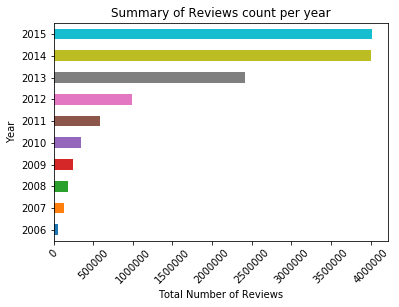

```python
plt.xticks(rotation=45)
(df.review_date.apply(lambda x:str(x).split('-')[0],meta=str).value_counts()
 .compute().iloc[0:10].sort_index().plot(kind='barh'))
plt.title('Summary of Reviews count per year')
plt.xlabel('Total Number of Reviews')
plt.ylabel('Year');
```

### Total Number of Review per month for different years

In this visualization, we are seeing the distribution of review counts at different months across the years. We can observe that most of the yearly peaks consistenly occur during months of December and January. These months are known for its long holidays.

```
[                                        ] | 0% Completed |  0.1s
```

```
[########################################] | 100% Completed |  3min 14.2s
```

[figure not shown]

```python
df['year'] = df.review_date.apply(lambda x: str(x).split('-')[0],meta=str)
df['month'] = df.review_date.apply(lambda x: str(x).split('-')[1] if len(str(x).split('-')) > 1 else None,meta=str)
temp = df.groupby('year')['month'].apply(lambda x:x.value_counts()).compute().sort_index()
temp.loc['2010':'2015'].plot(kind='barh',figsize=(20,20))
plt.title('Summary of Reviews count per month ')
plt.xlabel('Total Number of Reviews')
plt.ylabel('Year and Month')
```

### Total Number of Reviews per month for different years

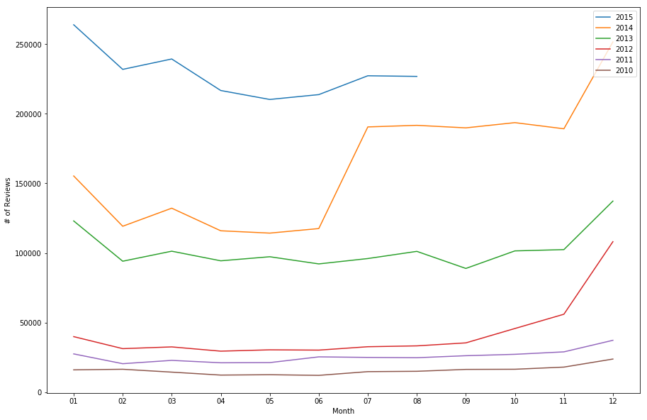

```python
plt.figure(figsize=(15,10))
plt.plot(temp.loc['2015'],label='2015')
plt.plot(temp.loc['2014'],label='2014')
plt.plot(temp.loc['2013'],label='2013')
plt.plot(temp.loc['2012'],label='2012')
plt.plot(temp.loc['2011'],label='2011')
plt.plot(temp.loc['2010'],label='2010')
plt.xlabel('Month')
plt.ylabel('# of Reviews')
plt.legend(loc='upper right')
plt.show()
```

### Total Number of Reviews per category across different months

```python
df_verified = df[df.verified_purchase == 'Y']
df_verified.star_rating = df_verified.star_rating.astype(int)
df_verified.helpful_votes = df_verified.helpful_votes.astype(int)
df_verified.total_votes = df_verified.total_votes.astype(int)
```

```python
df_verified['month'] = df_verified.review_date.apply(
    lambda x: str(x).split('-')[1] if len(str(x).split('-')) > 1 else None, meta=str)
```

```python
df_verified['year'] = df_verified.review_date.apply(
    lambda x: str(x).split('-')[0], meta=str)
```

```python
labcol = ['C0', 'C1', 'C2', 'C3', 'C4', 'C5', 'C6', 'C7', 'C8', 'C9']
xticks = ['Jan', 'Feb', 'Mar', 'Apr', 'May', 'Jun',
          'Jul', 'Aug', 'Sep', 'Oct', 'Nov', 'Dec']
months = np.arange(1, 13)
categories = ['Sports', 'Shoes', 'Automotive', 'Electronics',
              'Pet Products', 'Grocery', 'Camera', 'Video Games', 'Watches', 'Musical Instruments']
```

```python
df_reviews = df_verified.groupby(['month', 'product_category'])['review_id'].count().compute()
```

```
[########################################] | 100% Completed |  6min 22.5s
```

In the visualization below, we can see which among the selected categories received most number of reviews from verified purchasers. We can observe at which months most reviews are being written and which months have fewer activities of reviews posting. Notice that there is a dip of counts on the last quarter of the year, which is caused by missing values on the last quarter of 2015. With this, we created a new visualization below that does not include 2015 reviews.

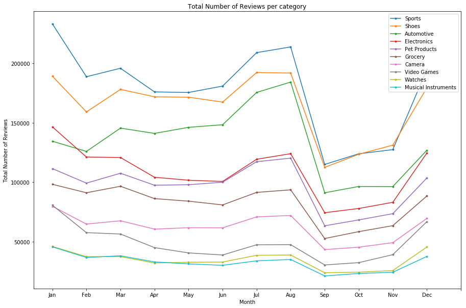

```python
plt.figure(figsize=(15,10))

for cat in categories:
    cat_keys = df_reviews[:,cat].keys().values.tolist()
    counts = []
    for m in months:
        if m > 9:
            k = str(m)
        else:
            k = '0' + str(m)

        if k in cat_keys:
            counts.append(df_reviews[k,cat])
        else:
            counts.append(0)

    plt.plot(counts, '.-', label=cat)

plt.title('Total Number of Reviews per category')
plt.xlabel('Month')
plt.ylabel('Total Number of Reviews')
plt.xticks(np.arange(13),xticks);
plt.legend();
```

From the visualization below, we can see that the peak of reviews are written on December and January, which started to increase at the start of the midyear. We can also observe that products under sports and shoes categories are most reviewed and are most related product categories. We can also see that automotive and electronics are both well-reviewed on December. However, electronics are more reviewed on January, which can probably be associated more people who decided to buy products during sale and holiday seasons in December and wrote reviews after month of buying. Based on the patterns we saw, we can associate the increase in number of reviews on seasons/durations wherein people have the opportunity to buy more products because of price discouts, increase in customers' purchasing capacity and leisure time.

```python
df_reviews_no2015 = df_verified[df_verified.year != '2015'].groupby(['month', 'product_category'])['review_id'].count().compute()
```

```
[########################################] | 100% Completed |  7min 46.4s
```

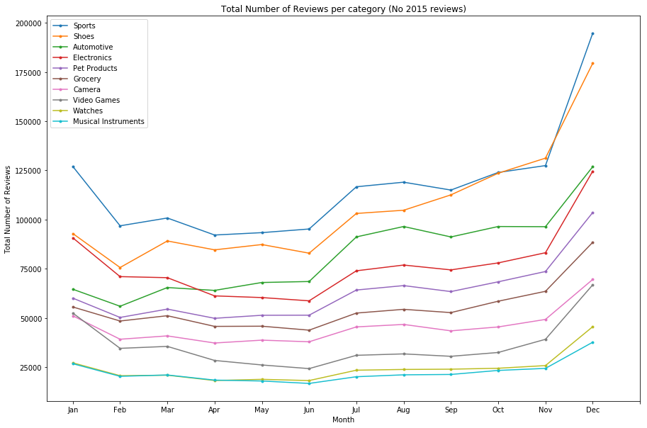

```python
plt.figure(figsize=(15,10))

for cat in categories:
    cat_keys = df_reviews_no2015[:,cat].keys().values.tolist()
    counts = []
    for m in months:
        if m > 9:
            k = str(m)
        else:
            k = '0' + str(m)

        if k in cat_keys:
            counts.append(df_reviews_no2015[k,cat])
        else:
            counts.append(0)

    plt.plot(counts, '.-', label=cat)

plt.title('Total Number of Reviews per category (No 2015 reviews)')
plt.xlabel('Month')
plt.ylabel('Total Number of Reviews')
plt.xticks(np.arange(13),xticks);
plt.legend();
```

### Mean Ratings per product category

Below are 2 visualizations of mean ratings per product category.

```python
df_novote = df_verified[df_verified.total_votes == 0]
df_helpful = df_verified[df_verified.helpful_votes > 1]
```

```python
df_all_ratings = df_verified.groupby(['month', 'product_category'])['star_rating'].mean().compute()
```

```
[########################################] | 100% Completed |  5min 56.3s
```

```python
df_novote_ratings = df_novote.groupby(['month', 'product_category'])['star_rating'].mean().compute()
```

```
[########################################] | 100% Completed |  5min 59.5s
```

```python
df_helpful_ratings = df_helpful.groupby(['month', 'product_category'])['star_rating'].mean().compute()
```

```
[########################################] | 100% Completed |  6min 10.9s
```

In the first visualization, we can observe that grocery products relatively acquires the highest star ratings while electronic products acquires lowest star ratings all through out the year among all the categories. Some product categories received the highest ratings during January and December, notably for Video Games and Electronics.

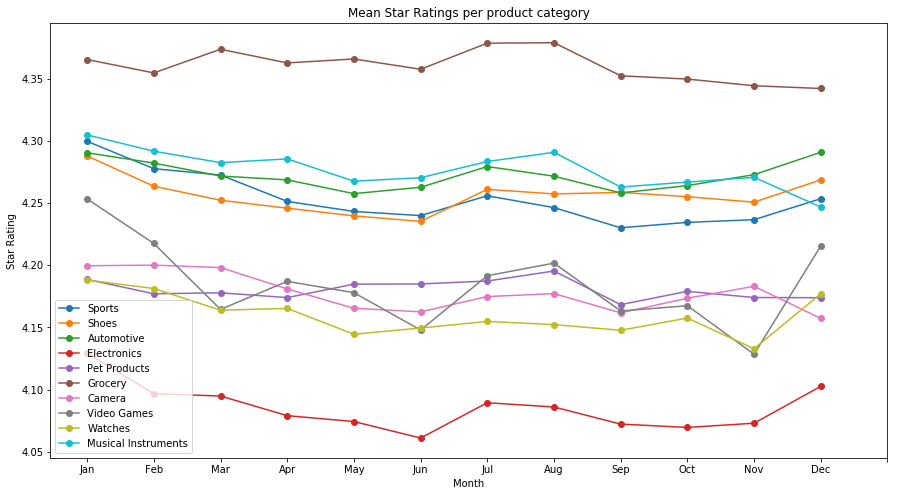

```python
plt.figure(figsize=(15,8))
i = 0
for cat in categories:
    cat_keys = df_all_ratings[:,cat].keys().values.tolist()
    counts = []
    for m in months:
        if m > 9:
            k = str(m)
        else:
            k = '0' + str(m)

        if k in cat_keys:
            counts.append(df_all_ratings[k,cat])
        else:
            counts.append(0)

    plt.plot(counts, 'o-', label=cat, color=labcol[i])
    i+=1

plt.title('Mean Star Ratings per product category')
plt.xlabel('Month')
plt.ylabel('Star Rating')
plt.legend();
plt.xticks(np.arange(13),xticks);
# plt.ylim(3.5,4.5)
```

The 2nd visualization shows the mean ratings for those product reviews with no votes yet and those product reviews with helpful votes. We can see here that star ratings for those with existing helpful votes have relatively lower value than those with no votes yet. We believe that there is much product scrutiny or expectations unmet upon seeing previous votes. This time, Video Games product category receives the lowest ratings among others.

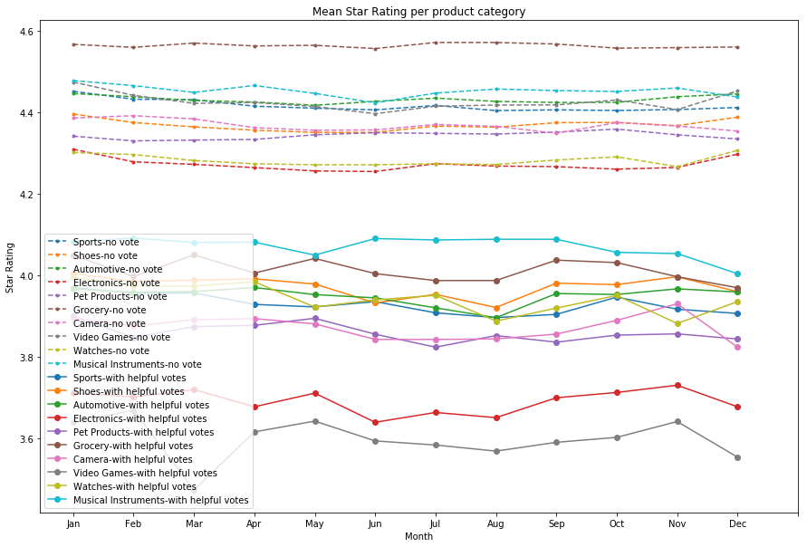

```python
plt.figure(figsize=(15,10))

i = 0
for cat in categories:
    cat_keys = df_novote_ratings[:,cat].keys().values.tolist()
    counts = []
    for m in months:
        if m > 9:
            k = str(m)
        else:
            k = '0' + str(m)

        if k in cat_keys:
            counts.append(df_novote_ratings[k,cat])
        else:
            counts.append(0)

    plt.plot(counts, '.--', label=cat + '-no vote', color=labcol[i])
    i+=1

i = 0
for cat in categories:
    cat_keys = df_helpful_ratings[:,cat].keys().values.tolist()
    counts = []
    for m in months:
        if m > 9:
            k = str(m)
        else:
            k = '0' + str(m)

        if k in cat_keys:
            counts.append(df_helpful_ratings[k,cat])
        else:
            counts.append(0)

    plt.plot(counts, 'o-', label=cat + '-with helpful votes', color=labcol[i])
    i+=1

plt.title('Mean Star Rating per product category')
plt.xlabel('Month')
plt.ylabel('Star Rating')
plt.legend();
plt.xticks(np.arange(13),xticks);
# plt.ylim(3.5,4.5)
```

### Mean ratings given by helpful customers

```python
df['year'] = df.review_date.apply(lambda x: str(x).split('-')[0],meta=str)
df['month'] = df.review_date.apply(lambda x: str(x).split('-')[1] if len(str(x).split('-')) > 1 else None,meta=str)
```

```python
array = ['2010','2011','2012','2013','2014','2015']
df=df.loc[df['year'].isin(array)]
df['helpful_votes'] = df['helpful_votes'].astype(np.int32)
df['star_rating'] = df['star_rating'].astype(np.int8)
helpful_customer= df[df['helpful_votes']>10]#arbitrary value
```

We can see here the distribution of mean ratings from all products.

```
[########################################] | 100% Completed |  5min 45.4s
```

```
Text(0,0.5,'Total Number of Helpful Customer')
```

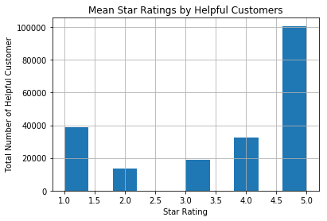

```python
g1 =(helpful_customer[['customer_id','helpful_votes','star_rating','product_title']]
.groupby('customer_id')['star_rating'].mean().astype(np.int8).compute()).hist()
plt.title('Mean Star Ratings by Helpful Customers')
plt.xlabel('Star Rating')
plt.ylabel('Total Number of Helpful Customer')
```

### Items with the most 5-star ratings and their quantity

Based on the distribution above, we looked for what items received the most number of 5-star and 1-star ratings. Notice that the items `electronics` Panasonic ErgoFit In-Ear Earbud Headphones, `grocery` San Francisco Bay One Cup, and `video games` Playstation 4 500GB Console (Old Model) received the most number of reviews per product category.

```
[########################################] | 100% Completed |  7min 32.2s
```

```
Text(0,0.5,'Product Title')
```

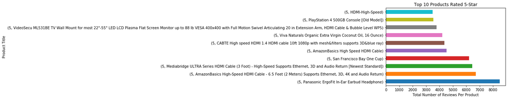

```python
df[df['star_rating']==5].groupby('star_rating')['product_title'].apply(lambda x:x.value_counts().nlargest(10)).compute().plot.barh()
plt.title('Top 10 Products Rated 5-Star')
plt.xlabel('Total Number of Reviews Per Product')
plt.ylabel('Product Title')
```

### Items with the most 1-star reviews and their quantity

Most of the items with 1-star ratings fall under product category Video Games. We can say that customers under these category are hobbyists, and are more scrutinizing when it comes to product features and quality as compared to other product categories. This is a challenge for sellers to take note of the reviews for product improvement.

```
[########################################] | 100% Completed |  5min 55.1s
```

```
Text(0,0.5,'Product Title')
```

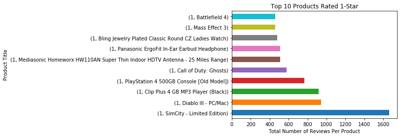

```python
df[df['star_rating']==1].groupby('star_rating')['product_title'].apply(lambda x:x.value_counts().nlargest(10)).compute().plot(kind='barh')
plt.title('Top 10 Products Rated 1-Star')
plt.xlabel('Total Number of Reviews Per Product')
plt.ylabel('Product Title')
```

### Most reviewed products during peak review season, December

Most reviewed products during December fall under categories video games and electronics, which is consistent with previous plots. If the sellers are able to improve those video game products that are rated 1-star, this may result to an increase of online presence and sales.

```
[########################################] | 100% Completed |  5min 47.1s
```

```
Text(0,0.5,'Product Title')
```

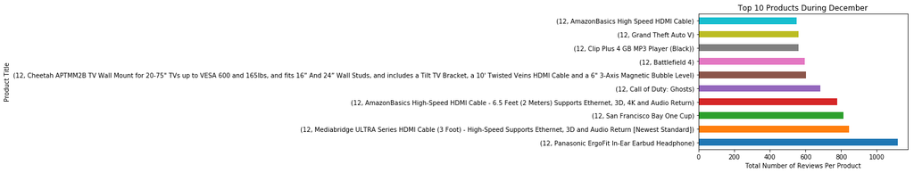

```python
df[df['month']=='12'].groupby('month')['product_title'].apply(lambda x:x.value_counts().nlargest(10)).compute().plot(kind='barh')
plt.title('Top 10 Products During December')
plt.xlabel('Total Number of Reviews Per Product')
plt.ylabel('Product Title')
```

## VII. References

https://s3.amazonaws.com/amazon-reviews-pds/readme.html  
https://www.linkedin.com/pulse/what-importance-reviews-amazon-amazon-ranking-expert/  
https://en.wikipedia.org/wiki/Amazon_(company)